# Data Module 3: Colorado’s MMI

# Tutorial + Assignment

- The full tutorial and assignment description are in this single document.

# Overview

This data module is made up of three parts

1. Entering data from the Las Animas River spill into a shared Google Sheets file
2. Example of Colorado’s MMI on the Bonita Peak data
3. Calculating simple metrics and Colorado’s MMI Score on the Animas River data

# Background - Las Animas River Spill

- On August 5th, 2015, EPA contractors accidentally destroyed a plug holding contaminated water in tunnels of the Gold King Mine
- Released ~3m US Gallons Wastewater
  - pH ~ 3
  - contained heavy metals inclusing Cd, Pb, As, Zn, Fe, Cu, Be
- Water in Durango, CO contaminated From ~Aug 5th to 10th
  - Acute exposure
  - Very high concentrations for a relatively short time
- Contaminated flood pulse reached Lake Powell Aug 14th.
- UT Division of Water Quality determined dilution at this point sufficient

# Las Animas Data

- [Mountain Studies Institute](https://www.mountainstudies.org/) conducted a sampling effort immediately after the spill.
- Limited longitudinal sampling of the Las Animas above (A68, reference) and below the spill (A72, impacted)
  - Reference and impacted sample is separated in space
    - Prediction: Negative effects of the spill will be detected when comparing samples taken above and below the release location.
  - Repeat samples were taken 2-7 days and 6-8 weeks afterwards
    - Prediction: Negative effects will diminish through time and the community will show signs of recovery (compare results from first sample date collection to results of later dates).
- Some sites near Durango were able to be sampled *before* the contamination arrived
  - Reference and impacted samples are separated through time.
    - Prediction: The community will show negative effects when comparing samples before and immediately after the spill.
  - Repeat samples were taken 2-7 days and 6-8 weeks afterwards
    - Prediction: Negative effects will lessen through time and show signs of recovery in later samples.
- Samples were also collected longitudinally 6-8 weeks after the spill.
  - Paired samples were collected along the main stem of the Las Animas (impacted) as well as along tributaries (unimpacted)
  - Test for the effects of dilution
    - Prediction: Impacts will be strongest up stream, and decrease as more tributaries come in and dilute the contamination

Table 1. Sample names ordered from up- to downstream. All sites are located on the main stem of the Las Animas River unless indicated as a tributary in parentheses. Sample dates are given with their time relative to the spill arrival at that site. The predicted impact category is listed. See also Figure 1. which is a map of the sample locations.

| Full Site Name | Before spill | ~24h post spill | ~1 week post spill | 6-8 weeks post spill | Impact category |
| --- | --- | --- | --- | --- | --- |
| A55 - Howardsville |  |  |  | 2015-09-23 | Reference |
| A60 - Below Arrastra |  |  |  | 2015-09-23 | Reference |
| A68 - Above Cement |  | 2015-08-08 | 2015-08-12 | 2015-09-23 | Reference |
| A72 - Below Silverton |  | 2015-08-08 | 2015-08-12 | 2015-09-23 | Impacted |
| A73 - Above Elk |  |  |  | 2015-10-15 | Impacted |
| A73EC - Elk Creek (trib) |  |  |  | 2015-10-15 | Reference |
| A75D - Above Cascade |  |  |  | 2015-10-15 | Impacted |
| A75CC - Cascade (trib) |  |  |  | 2015-10-15 | Reference |
| Baker’s Bridge |  |  |  | 2015-09-21 | Impacted |
| James Ranch |  |  |  | 2015-09-21 | Impacted |
| Oxbow Park |  |  |  | 2015-09-18 | Impacted |
| 32nd Street | 2015-08-06 | 2015-08-07 | 2015-08-13 | 2015-09-22 | Depends on date |
| Rotary Park | 2015-08-06 | 2015-08-07 | 2015-08-13 | 2015-09-20 | Depends on date |
| Above Lightner |  |  |  | 2015-09-20 | Impacted |
| Purple Cliffs |  |  |  | 2015-09-22 | Impacted |

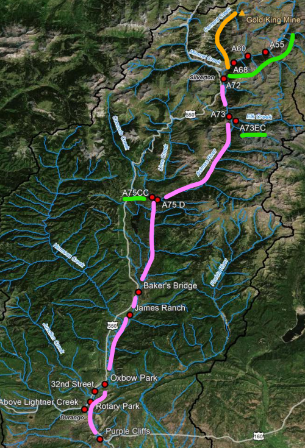

Figure 1. Map showing sample locations assessing impacts of the Gold King Mine spill. The Las Animas River above the spill, as well as downstream tributaries, are indicated in Green (assumed no impact). The spill followed Cement Creek which is indicated in Orange. Sites downstream of the confluence with Cement Creek are indicated in Pink (assumed to be impacted, depending on sample date). Figure modified from MSI report (2016).

# Part 1 Data Entry

**Warning**

- Attention to detail is critical
- I discuss some specific points to watch out for below
- In general, remember that:

> Computers are very powerful but very stupid
- R won’t know that `sample date` is the same thing as `Sample_date` or that `zpda` is the same thing as `Zapada`, etc.
- Please take your time and make sure all the column names match the template provided, and all values entered are spelled correctly, in the proper format, etc.
- Each student is assigned one site-date combination to enter into a shared Google Sheets file
  - See D2L for your assignment, all the data, and the Google link which is current to this semester’s course
  - The entry assignment can be found in the “*Data_entry_student_assignments*” table
  - All the data is in the “*Data_to_enter*” pdf
- I will demonstrate how to enter the data in class, but keep the following in mind
  1. Open the Google Sheets link on D2L
     - Make sure it opens in a new tab: do **not** enter data in the D2L window
  2. Copy the information from the `Template` tab
  3. Create a new tab and name it with the site code and your name, e.g.:
     - A75CC - Justin
     - Bakers_Bridge - Vanessa
     - 32nd_Street - Hillary
     - etc.
  4. Make sure your `site_code` matches exactly what is in the *Data_entry_student_assignments* table
     - Good: `James_ranch`
     - **NOT GOOD:** jame’s ranch, James Ranch; jame’s-ranch; etc.
     - Good: `32nd_Street`
     - **NOT GOOD:** 32nd street, 32-Street, 32ND_STREET, etc.
  5. Enter the correct data that you were assigned
     - Look through the “*Data_to_enter*” document
     - Scroll down to find the table with your site code/name on it
     - Make sure the **site and date** combination is correct
  6. Most of the data you will enter is exactly as it appears on the sheet, but you will need to add the following from the assignment table
     - Biotype (2 or 1)
     - Sample date in proper SI format, separated with a - :
       - YYYY-MM-DD
       - `2015-10-15`
     - Sample month needs to be entered as two digits
       - **Correct**: `08`, `09`, `10`
       - **Incorrect:** 8, 9
  7. Type the `Taxon` name *EXACTLY* as it appears in the original data
     - e.g.,
       - Nemouridae_(not_zapada)
       - Eukiefferiella_gracei
       - Pteronarcys
       - etc.
     - Typos or different spellings will make analysis difficult
     - You will be responsible for fixing any typos or errors which are discovered
  8. All the data for your site-date combination needs to entered by the date and time listed on D2L.
     - **Your colleagues cannot complete the data assignment until all data is entered**
     - Late data entry will result in a 50% penalty on your total assignment grade.

# Part 2: Calculating Colorado’s MMI

## Overview

- Demonstrate how to calculate CO’s MMI using the `bonita_peak` data
- You will need to repeat this process once all the Las Animas River data is entered
- Note that some steps below only pertain to the `bonita_peak` data and do not need to be performed on the Las Animas data
  - I have tried to make this as clear as possible below.

# Setup

## Download files from D2L

- You should already have the `bonita_peak.csv` downloaded in your `data/` folder from the first module, but download it again if needed.
- Download the `MMI_taxa_info.csv` sheet from D2L and put it in your `data/` folder
- Download the `las_animas_categories.csv` sheet from D2L and put it in your `data/` folder
- You will also need to download the `Data_3_cusom_functions.R` script
  - Put this in your R project, **not** in the `data/` folder

## Load Libraries and data

- the `source()` command below runs the full script which contains custom functions for this module (more below)
- We will load the `bp` data as in the last module
- We will also load the new object which contains the site categories

```r
# Load custom functions
# You need to download this R script from D2L first
source("Data_3_custom_functions.R")

# load library
library(tidyverse)

# read in data
# you should already have these downloaded from previous tutorials
bp <- read_csv("data/bonita_peak.csv")
bp_categories <- read_csv("data/site_categories_training.csv") |>
  mutate(site_category = factor(
    site_category,
    levels = c("reference",
               "light",
               "heavy",
               "test")))

# new data to load
# make sure to download these first and put them in your "data/" folder.
taxa <- read_csv("data/MMI_taxa_info.csv")
animas_categories <- read_csv("data/las_animas_categories.csv") |>
  mutate(site_category = factor(
    site_category,
    levels = c("reference",
               "impacted")))
```

- View the data objects

```r
head(bp)
```

```
# A tibble: 6 × 13
  stream   site  site_id taxon total_count count phylum class order family genus
  <chr>    <chr> <chr>   <chr>       <dbl> <dbl> <chr>  <chr> <chr> <chr>  <chr>
1 mill_cr  abv_… MILaM   Amel…       12640    16 Arthr… Inse… Ephe… Amele… Amel…
2 bear_cr  abv_… BEaM    Amel…        2832     5 Arthr… Inse… Ephe… Amele… Amel…
3 sf_anim… abv_… SFAaAV  Amel…        5384    16 Arthr… Inse… Ephe… Amele… Amel…
4 sf_anim… abv_… SFAaEU  Amel…         668     3 Arthr… Inse… Ephe… Amele… Amel…
5 eureka_… abv_… EUaSFA  Amel…         622     1 Arthr… Inse… Ephe… Amele… Amel…
6 sf_anim… abv_… SFAaA   Amel…        1437     5 Arthr… Inse… Ephe… Amele… Amel…
# ℹ 2 more variables: habit <chr>, FFG <chr>
```

```r
head(taxa)
```

```
# A tibble: 6 × 11
  Taxon              Phylum Class Order Family Genus Habit FFG   Bio_1_sensitive
  <chr>              <chr>  <chr> <chr> <chr>  <chr> <chr> <chr> <lgl>
1 Ameletus           Arthr… Inse… Ephe… Amele… Amel… clin… scra… TRUE
2 Amphinemura        Arthr… Inse… Plec… Nemou… Amph… spra… shre… TRUE
3 Antocha            Arthr… Inse… Dipt… Tipul… Anto… burr… pred… FALSE
4 Apedilum           Arthr… Inse… Dipt… Chiro… Aped… burr… coll… FALSE
5 Arctopsyche        Arthr… Inse… Tric… Hydro… <NA>  clin… filt… FALSE
6 Arctopsyche_grand… Arthr… Inse… Tric… Hydro… <NA>  clin… filt… FALSE
# ℹ 2 more variables: Bio_1_tolerant <lgl>, Bio_2_sensitive <lgl>
```

## Modify `bp` data

- The following step is required to get the `bp` object into the same format as the Las Animas data that you will enter
- You **do** **not need to** **repeat** the next step for your homework assignment.

```r
colnames(bp) <- str_to_sentence(colnames(bp))
bp$Biotype <- 2
bp$Sample_date <- "2016-10-17"
head(bp)
```

```
# A tibble: 6 × 15
  Stream   Site  Site_id Taxon Total_count Count Phylum Class Order Family Genus
  <chr>    <chr> <chr>   <chr>       <dbl> <dbl> <chr>  <chr> <chr> <chr>  <chr>
1 mill_cr  abv_… MILaM   Amel…       12640    16 Arthr… Inse… Ephe… Amele… Amel…
2 bear_cr  abv_… BEaM    Amel…        2832     5 Arthr… Inse… Ephe… Amele… Amel…
3 sf_anim… abv_… SFAaAV  Amel…        5384    16 Arthr… Inse… Ephe… Amele… Amel…
4 sf_anim… abv_… SFAaEU  Amel…         668     3 Arthr… Inse… Ephe… Amele… Amel…
5 eureka_… abv_… EUaSFA  Amel…         622     1 Arthr… Inse… Ephe… Amele… Amel…
6 sf_anim… abv_… SFAaA   Amel…        1437     5 Arthr… Inse… Ephe… Amele… Amel…
# ℹ 4 more variables: Habit <chr>, Ffg <chr>, Biotype <dbl>, Sample_date <chr>
```

```r
colnames(bp_categories) <- str_to_sentence(colnames(bp_categories))
head(bp_categories)
```

```
# A tibble: 6 × 2
  Site_id Site_category
  <chr>   <fct>
1 AaEU    light
2 AaMINN  heavy
3 BUaNFA  test
4 MaMIL   test
5 MaSFM   heavy
6 MFMaM   test
```

## Calculate CO’s MMI

- The following steps will need to be repeated on the Las Animas River data for your homework assignment.
- Join the `taxa` information to the `bp` data

```r
bp <- inner_join(bp, taxa)
head(bp)
```

```
# A tibble: 6 × 19
  Stream   Site  Site_id Taxon Total_count Count Phylum Class Order Family Genus
  <chr>    <chr> <chr>   <chr>       <dbl> <dbl> <chr>  <chr> <chr> <chr>  <chr>
1 mill_cr  abv_… MILaM   Amel…       12640    16 Arthr… Inse… Ephe… Amele… Amel…
2 bear_cr  abv_… BEaM    Amel…        2832     5 Arthr… Inse… Ephe… Amele… Amel…
3 sf_anim… abv_… SFAaAV  Amel…        5384    16 Arthr… Inse… Ephe… Amele… Amel…
4 sf_anim… abv_… SFAaEU  Amel…         668     3 Arthr… Inse… Ephe… Amele… Amel…
5 eureka_… abv_… EUaSFA  Amel…         622     1 Arthr… Inse… Ephe… Amele… Amel…
6 sf_anim… abv_… SFAaA   Amel…        1437     5 Arthr… Inse… Ephe… Amele… Amel…
# ℹ 8 more variables: Habit <chr>, Ffg <chr>, Biotype <dbl>, Sample_date <chr>,
#   FFG <chr>, Bio_1_sensitive <lgl>, Bio_1_tolerant <lgl>,
#   Bio_2_sensitive <lgl>
```

- Calculate the individual metrics of the MMI

**Note**

- Note that the `bp` data only has Biotype 2 so we can apply this to the full object.
- The Las Animas River data has sites in Biotype 1 and in Biotype 2
- You will need to separate them into different data objects
- Also, for Biotype 1, there are additional custom functions and they are named:
  - `calc_bio1_metrics()`
  - `bio1_mmi()`

```r
bp_metrics <- calc_bio2_metrics(bp, group_column = Site_id)
```

```
`summarise()` has regrouped the output.
ℹ Summaries were computed grouped by Sample_date and Site_id.
ℹ Output is grouped by Sample_date.
ℹ Use `summarise(.groups = "drop_last")` to silence this message.
ℹ Use `summarise(.by = c(Sample_date, Site_id))` for per-operation grouping
  (`?dplyr::dplyr_by`) instead.
```

```r
head(bp_metrics)
```

```
# A tibble: 6 × 10
# Groups:   Sample_date [1]
  Sample_date Site_id TotalTax aEPTTax pEPTnoB ClngrTax IntolTax pi_DecrMtnTrn
  <chr>       <chr>      <int>   <int>   <dbl>    <int>    <int>         <dbl>
1 2016-10-17  AaARR         20      13  45.5         10        9        32.1
2 2016-10-17  AaCU          22      14  77.8         11       10        34.6
3 2016-10-17  AaEU           9       8  98.8          6        6        38.8
4 2016-10-17  AaMINN        19      11  70.5          9        8        37.7
5 2016-10-17  BEaM          27      16  82.5         14       13        60.9
6 2016-10-17  BUaNFA         7       1   0.506        0        0         0.506
# ℹ 2 more variables: PredTaxFAC <int>, ScrapPctFAC <dbl>
```

- Calculate the total score for the Biotype 2 sites

```r
bp_mmi <- bio2_mmi(bp_metrics, Site_id)
bp_mmi
```

```
# A tibble: 25 × 3
# Groups:   Sample_date [1]
   Site_id Sample_date mmi_score
   <chr>   <chr>           <dbl>
 1 AaARR   2016-10-17      47.2
 2 AaCU    2016-10-17      57.6
 3 AaEU    2016-10-17      40.3
 4 AaMINN  2016-10-17      45.6
 5 BEaM    2016-10-17      69.6
 6 BUaNFA  2016-10-17       3.72
 7 EUaSFA  2016-10-17      53.2
 8 HERaD   2016-10-17      42.5
 9 MAGaA   2016-10-17      59.1
10 MFMaM   2016-10-17      19.7
# ℹ 15 more rows
```

- Join the data with the “known” impact categories for the Bonita Peak data

```r
bp_mmi <- left_join(bp_mmi, bp_categories)
bp_mmi
```

```
# A tibble: 25 × 4
# Groups:   Sample_date [1]
   Site_id Sample_date mmi_score Site_category
   <chr>   <chr>           <dbl> <fct>
 1 AaARR   2016-10-17      47.2  light
 2 AaCU    2016-10-17      57.6  light
 3 AaEU    2016-10-17      40.3  light
 4 AaMINN  2016-10-17      45.6  heavy
 5 BEaM    2016-10-17      69.6  reference
 6 BUaNFA  2016-10-17       3.72 test
 7 EUaSFA  2016-10-17      53.2  light
 8 HERaD   2016-10-17      42.5  reference
 9 MAGaA   2016-10-17      59.1  test
10 MFMaM   2016-10-17      19.7  test
# ℹ 15 more rows
```

- Plot the scores along with the cutoff values

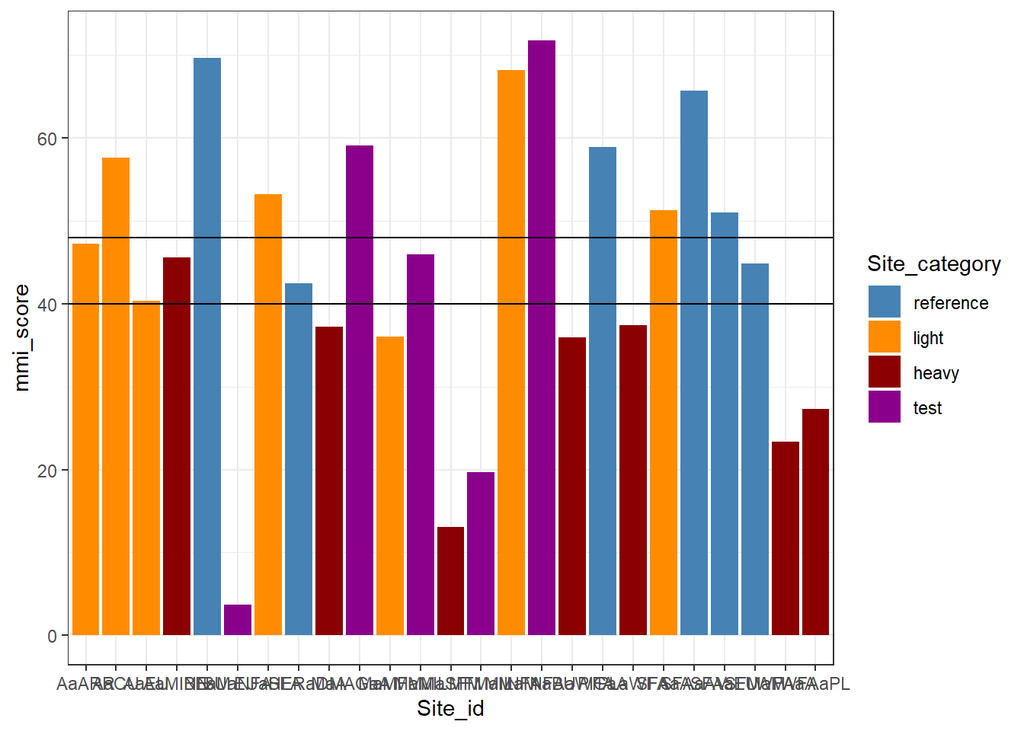

```r
ggplot(bp_mmi,
       aes(x = Site_id,
           y = mmi_score,
           fill = Site_category)) +
  geom_col() +
  geom_hline(aes(yintercept = 48))+
  geom_hline(aes(yintercept = 40))
```

- We will not be spending too much time interpreting this
- But note that *most* of the Heavy Impacts (dark red) are below the lower cutoff
- Likewise, many of the Reference streams (Steel Blue) are above the upper cutoff.
- The Light Impacts (Orange) are all over the place, but remember our discussion about how light impacts are more of a gradient designation as opposed to a discrete cutoff.

**Note**

- Note that Biotype 1 has different cutoff values:
  - 44 and 35
- You will need to change the values in the `yintercept =` argument in both `geom_hline()` calls above when plotting the results for your biotype 1 sites.

# Part 3: Homework

Calculate simple metrics and MMI scores for the Las Animas River Data.

## Overview

1. Load the data from the shared Google Sheets
2. Cut the data into different pieces based on hypotheses
3. Calculate simple metrics for longitudinal data
4. Calculate MMI scores for Biotype 1 and 2 as appropriate
5. Recombine results to answer specific predictions

## Download data from Google Sheets

- install the `googlesheets4` package by running the following in your console
  - **NOTE**: do **NOT** put this in your script, just run it once in your console
  - `install.packages(googlesheets4)`
- Load the library and prepare the session

```r
library(googlesheets4)
# prep the session
gs4_deauth()
```

- copy the sheet URL
  - Probably easiest to copy from the link on D2L

```r
# this is the link for FA2026
# MAke sure it's updated for future classes
sheet_url <- "https://docs.google.com/spreadsheets/d/1wXRXqfBh6_ZDQVxkUaPT4DmoNSPi477qVDyDgnktajs/edit?usp=sharing/"

sheet_names <- sheet_names(sheet_url)
sheet_names <- sheet_names[sheet_names != "Template"]
sheet_names
```

```
[1] "A75D Ava"     "A73 Deklan"   "A75CC-Justin"
```

- read in data stored in Google Sheet

```r
animas_data <- map_dfr(sheet_names, function(tab) {
  read_sheet(sheet_url,
             sheet = tab,
             col_types = "cicdDdc")  # tag rows with source tab
  # c = character
  # i = integer
  # d = double
  # D = date
})
```

```
✔ Reading from "ENVS 337 MMI Data FA26".
```

```
✔ Range ''A75D Ava''.
```

```
✔ Reading from "ENVS 337 MMI Data FA26".
```

```
✔ Range ''A73 Deklan''.
```

```
✔ Reading from "ENVS 337 MMI Data FA26".
```

```
✔ Range ''A75CC-Justin''.
```

```r
animas_data
```

```
# A tibble: 82 × 8
   `Site Code` Biotype Taxon   Count Sample_date Sample_month_mm Entered_by_name
   <chr>         <int> <chr>   <dbl> <date>                <dbl> <chr>
 1 A75D              2 Baetis      1 2015-10-15               10 Ava
 2 A75D              2 Drunel…     2 2015-10-15               10 Ava
 3 A75D              2 Rithro…    31 2015-10-15               10 Ava
 4 A75D              2 Capnia      1 2015-10-15               10 Ava
 5 A75D              2 Suwall…     1 2015-10-15               10 Ava
 6 A75D              2 Zapada      2 2015-10-15               10 Ava
 7 A75D              2 Hesper…     2 2015-10-15               10 Ava
 8 A75D              2 Taenio…    23 2015-10-15               10 Ava
 9 A75D              2 Arctop…    25 2015-10-15               10 Ava
10 A75D              2 Bibioc…     8 2015-10-15               10 Ava
# ℹ 72 more rows
# ℹ 1 more variable: site_code <chr>
```

### Load other data objects

- Make sure that the `taxa` and `animas_categories` objects are loaded.

### Join `taxa` info to `animas_data`

```r
animas_data <- inner_join(animas_data, taxa)
```

## Cut data into different pieces for separate analyses

- You will be testing two primary hypotheses
  1. The negative effects of contamination varied through time (hypothesis 1)
  2. The negative effects of contamination varied across space (hypothesis 2)
- For hypothesis 1, there are 4 sites (`A68`, `A72`, `32nd_Street` and `Rotary_Park`) which were sampled through time for a total of 14 samples.
- For hypothesis 2, all 15 sites were sampled 6-8 weeks after the spill in September or October (`Sample_month` = `09` or `10`)

### Data for hypothesis 1 - Time

- Because all the data is not yet entered, the following code will not modify our `animas_data` object
- However, you should be able to copy/paste and run the following code to set up your analysis

```r
hypo1 <- animas_data |>
  filter(site_code %in% c("A68", "A72", "32nd_Street", "Rotary_Park"))
# split based on biotype
hypo1_bio1 <- hypo1 |>
  filter(Biotype == 1)
hypo1_bio2 <- hypo1 |>
  filter(Biotype == 2)
```

### Data for hypothesis 2 - Space

- As above, once all the data is entered, you should be able to copy/paste and run the following code to set up your analysis

```r
hypo2 <- animas_data |>
  filter(Sample_month_mm == 09 |
           Sample_month_mm == 10)
# split based on biotype
hypo2_bio1 <- hypo2 |>
  filter(Biotype == 1)
hypo2_bio2 <- hypo2 |>
  filter(Biotype == 2)
```

## Calculate simple metrics - Hypothesis 2, Space

- Calculate three simple metrics of your choice for the `hypo2` data and make a plot for each result
- You will only do this on the data for `hypo2` since they were all collected around the same time and simple metrics don’t rely on biotype
- See Data Module 1 for examples of metrics
- the `calc_metrics()` function from data module 2 is not set up to work on the Animas River Data
- You will need to calculate the metrics of your choice “manually”
- Here, I will calculate one example to show you how to make a plot of the result.
- Your write up can include this if you want, but you will need to calculate three other metrics of your choice.

```r
metric_example <- hypo2 |>
  distinct(site_code, Sample_date, Taxon) |>
  group_by(site_code, Sample_date) |>
  summarize(total_rich = n())
```

```
`summarise()` has regrouped the output.
ℹ Summaries were computed grouped by site_code and Sample_date.
ℹ Output is grouped by site_code.
ℹ Use `summarise(.groups = "drop_last")` to silence this message.
ℹ Use `summarise(.by = c(site_code, Sample_date))` for per-operation grouping
  (`?dplyr::dplyr_by`) instead.
```

```r
metric_example
```

```
# A tibble: 3 × 3
# Groups:   site_code [3]
  site_code Sample_date total_rich
  <chr>     <date>           <int>
1 A73       2015-10-15          18
2 A75CC     2015-10-15          44
3 <NA>      2015-10-15          17
```

- Join the categories and plot

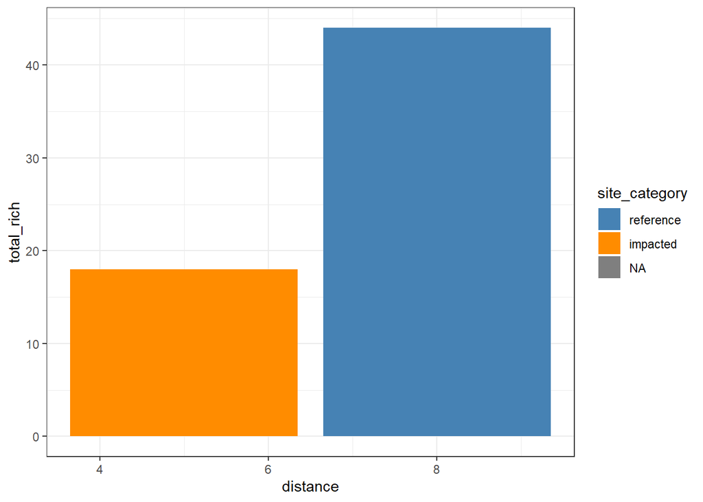

```r
metric_example <- metric_example |>
  left_join(animas_categories)
ggplot(metric_example,
       aes(x = distance,
           fill = site_category,
           y = total_rich)) +
  geom_col()
```

- Note that there is not cutoff here, but of the two sites that have data entered, one is Impacted and it has a lower value, whereas the reference site has a higher total taxonomic richness.

## Calculate MMI

- Calculate the MMI scores for all 4 data objects
- The following code is an example for 1 of the objects
- You will need to repeat this and modify as needed for the other 3 objects
  - Make sure to give each a unique name
  - Use the appropriate functions

```r
# calculate MMI metrics
hypo2_bio2_metrics <- calc_bio2_metrics(hypo2_bio2,
                                        group_column = site_code)
```

```
`summarise()` has regrouped the output.
ℹ Summaries were computed grouped by Sample_date and site_code.
ℹ Output is grouped by Sample_date.
ℹ Use `summarise(.groups = "drop_last")` to silence this message.
ℹ Use `summarise(.by = c(Sample_date, site_code))` for per-operation grouping
  (`?dplyr::dplyr_by`) instead.
```

```r
head(hypo2_bio2_metrics)
```

```
# A tibble: 3 × 10
# Groups:   Sample_date [1]
  Sample_date site_code TotalTax aEPTTax pEPTnoB ClngrTax IntolTax pi_DecrMtnTrn
  <date>      <chr>        <int>   <int>   <dbl>    <int>    <int>         <dbl>
1 2015-10-15  A73             18       8    88.3        7        5          22.9
2 2015-10-15  A75CC           44      19    64.1       18       14          45.2
3 2015-10-15  <NA>            17       7    63.5        5        3          16.5
# ℹ 2 more variables: PredTaxFAC <int>, ScrapPctFAC <dbl>
```

```r
# calculate MMI score
hypo2_bio2_mmi <- bio2_mmi(hypo2_bio2_metrics, site_code)
hypo2_bio2_mmi
```

```
# A tibble: 3 × 3
# Groups:   Sample_date [1]
  site_code Sample_date mmi_score
  <chr>     <date>          <dbl>
1 A73       2015-10-15       38.6
2 A75CC     2015-10-15       79.2
3 <NA>      2015-10-15       31.9
```

- Join the mmi results to the site information and make plots

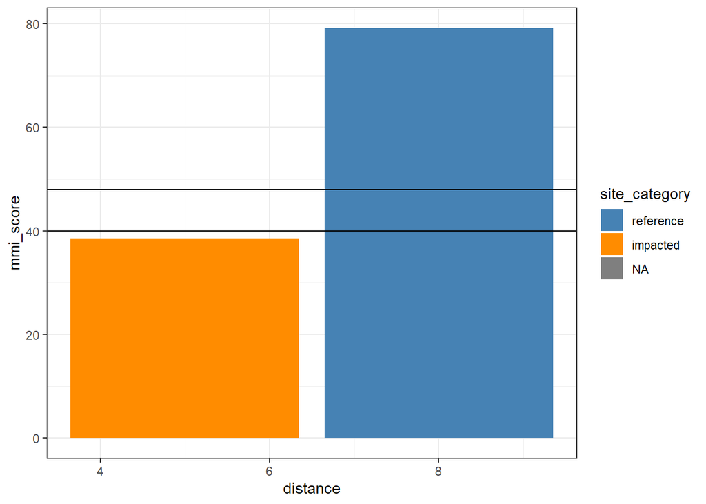

```r
hypo2_bio2_mmi |>
  left_join(animas_categories) |>
  ggplot(aes(x = distance,
           fill = site_category,
           y = mmi_score)) +
  geom_col() +
  geom_hline(aes(yintercept = 48))+
  geom_hline(aes(yintercept = 40))
```

**Note**

- For results from the `hypo1` data, there are multiple samples from the same site/distance downstream
- You will need to modify your code with the following changes:
  - Inside `aes()`, change `x = Sample_date`
  - Add another layer by putting a `+` sign after the last `geom_hline()` call, and then past the following:
  - `facet_wrap(~site_code, scales = "free_x")`

## Write up

- Complete the following in a word document and submit on D2L

### Simple Metrics - Variation through Space

1. List out the simple metrics you calculated for the `hypo2` data.
2. Include a plot for each metric.
   - Put `distance` on the x-axis and `site_category` as the fill
3. Fully interpret what you found with these metrics. Are there any patterns moving from up- to downstream? (Recall that there are two tributaries in the data as well.) Are there consistencies within or across metrics? In other words, did one or all metrics accurately follow the known impact categories? e.g., was one metric always high/low in reference/impacted streams?

### Hypothesis 1 - time

1. Make two plots for the results for hypothesis 1.
   - One plot is for biotype 1
   - One plot is for biotype 2
   - For both plots, put `Sample_date` on the x axis and `site_category` in the fill argument.
   - See note above about modifying the code to display the appropriate information.
   - Put the appropriate thresholds for biotype 1/2 on the correct plot
2. Fully interpret these results.
   - Remember that biotype 1 sites had samples before (reference) and after (impacted) the spill. - Are there any patterns that you notice? - What can you say about the prediction that negative effects will be seen, but they will improve through time?
   - Biotype 2 sites for this subset only had samples after the spill, but they were collected above (reference) and below (impacted) the confluence.
     - Are there any patterns that you notice?
     - What can you say about the prediction that negative effects will be seen, but they will improve through time?

### Hypothesis 2 - space

1. Make two plots for the results for hypothesis 2.
   - One plot is for biotype 1
   - One plot is for biotype 2
   - For both plots, put `distance` on the x axis.
     - Recall that there are two tributaries in this data
     - The tributaries are listed in the downstream order near their paired sites on the main stem
     - They should be listed as “reference” sites
   - Put the appropriate thresholds for biotype 1/2 on the correct plot
2. Fully interpret the results presented in both plots.
   - Are there any patterns that you notice?
   - What can you say about the prediction that negative effects will be seen near the confluence, but they will improve as you move downstream?

### Synthesis

1. Overall, what do you think these results mean? What was the impact of the Gold King Mine spill through space and time.
2. Do these results surprise you, or were they what you expected?
3. Recall that the MMI is designed to broadly assess quality for “aquatic life”, but is not overly sensitive to any specific stressors. How does this change how you would interpret or discuss these results? What information would you want to include when discussing these results with someone unfamiliar with Colorado’s MMI?

### Final thoughts

Feel free to share any other thoughts you have about this data, these results, the MMI, etc.